# Vehicle Fuel Economy Estimates, 1984-2017

## Preliminary Wrangling

The purpose of EPA’s fuel economy estimates is to provide a reliable basis for comparing vehicles. Most vehicles in the database (other than plug-in hybrids) have three fuel economy estimates: a “city” estimate that represents urban driving, in which a vehicle is started in the morning (after being parked all night) and driven in stop-and-go traffic; a “highway” estimate that represents a mixture of rural and interstate highway driving in a warmed-up vehicle, typical of longer trips in free-flowing traffic; and a “combined” estimate that represents a combination of city driving (55%) and highway driving (45%). Estimates for all vehicles are based on laboratory testing under standardized conditions to allow for fair comparisons.

EPA’s fuel economy values are good estimates of the fuel economy a typical driver will achieve under average driving conditions and provide a good basis to compare one vehicle to another. However, your fuel economy may be slightly higher or lower than EPA’s estimates. Fuel economy varies, sometimes significantly, based on driving conditions, driving style, and other factors.The data we will be looking at is taken from https://www.kaggle.com/epa/fuel-economy. This data set contains 38113 row with 81 variables.

```python
import numpy as np
import pandas as pd
import matplotlib.pyplot as plt
import seaborn as sb


%matplotlib inline
```

```python
import warnings
warnings.filterwarnings('ignore')
```

```python
# load in the dataset into a pandas dataframe, print statistics
fuel = pd.read_csv("Vehicle Fuel Economy Estimates.csv")
```

```python
# show the row and columns
fuel.shape
```

```
(38113, 81)
```

```python
# show the types and non_null
fuel.info()
```

```
<class 'pandas.core.frame.DataFrame'>
RangeIndex: 38113 entries, 0 to 38112
Data columns (total 81 columns):
 #   Column                               Non-Null Count  Dtype
---  ------                               --------------  -----
 0   Vehicle ID                           38113 non-null  int64
 1   Year                                 38113 non-null  int64
 2   Make                                 38113 non-null  object
 3   Model                                38113 non-null  object
 4   Class                                38113 non-null  object
 5   Drive                                36924 non-null  object
 6   Transmission                         38102 non-null  object
 7   Transmission Descriptor              15045 non-null  object
 8   Engine Index                         38113 non-null  int64
 9   Engine Descriptor                    22693 non-null  object
```

[output cut: 73 more lines]

```python
# show the frist 5 of dataframe
fuel.head()
```

|  | Vehicle ID | Year | Make | Model | Class | Drive | Transmission | Transmission Descriptor | Engine Index | Engine Descriptor | ... | Hours to Charge (AC 240V) | Composite City MPG | Composite Highway MPG | Composite Combined MPG | Range (FT1) | City Range (FT1) | Highway Range (FT1) | Range (FT2) | City Range (FT2) | Highway Range (FT2) |
| --- | --- | --- | --- | --- | --- | --- | --- | --- | --- | --- | --- | --- | --- | --- | --- | --- | --- | --- | --- | --- | --- |
| 0 | 26587 | 1984 | Alfa Romeo | GT V6 2.5 | Minicompact Cars | NaN | Manual 5-Speed | NaN | 9001 | (FFS) | ... | 0.0 | 0 | 0 | 0 | 0 | 0.0 | 0.0 | NaN | 0.0 | 0.0 |
| 1 | 27705 | 1984 | Alfa Romeo | GT V6 2.5 | Minicompact Cars | NaN | Manual 5-Speed | NaN | 9005 | (FFS) CA model | ... | 0.0 | 0 | 0 | 0 | 0 | 0.0 | 0.0 | NaN | 0.0 | 0.0 |
| 2 | 26561 | 1984 | Alfa Romeo | Spider Veloce 2000 | Two Seaters | NaN | Manual 5-Speed | NaN | 9002 | (FFS) | ... | 0.0 | 0 | 0 | 0 | 0 | 0.0 | 0.0 | NaN | 0.0 | 0.0 |
| 3 | 27681 | 1984 | Alfa Romeo | Spider Veloce 2000 | Two Seaters | NaN | Manual 5-Speed | NaN | 9006 | (FFS) CA model | ... | 0.0 | 0 | 0 | 0 | 0 | 0.0 | 0.0 | NaN | 0.0 | 0.0 |
| 4 | 27550 | 1984 | AM General | DJ Po Vehicle 2WD | Special Purpose Vehicle 2WD | 2-Wheel Drive | Automatic 3-Speed | NaN | 1830 | (FFS) | ... | 0.0 | 0 | 0 | 0 | 0 | 0.0 | 0.0 | NaN | 0.0 | 0.0 |

5 rows × 81 columns

```python
# show the last 5 of dataframe
fuel.tail()
```

|  | Vehicle ID | Year | Make | Model | Class | Drive | Transmission | Transmission Descriptor | Engine Index | Engine Descriptor | ... | Hours to Charge (AC 240V) | Composite City MPG | Composite Highway MPG | Composite Combined MPG | Range (FT1) | City Range (FT1) | Highway Range (FT1) | Range (FT2) | City Range (FT2) | Highway Range (FT2) |
| --- | --- | --- | --- | --- | --- | --- | --- | --- | --- | --- | --- | --- | --- | --- | --- | --- | --- | --- | --- | --- | --- |
| 38108 | 37564 | 2017 | Volvo | XC60 FWD | Small Sport Utility Vehicle 2WD | Front-Wheel Drive | Automatic (S8) | NaN | 90 | SIDI | ... | 0.0 | 0 | 0 | 0 | 0 | 0.0 | 0.0 | NaN | 0.00 | 0.0 |
| 38109 | 37547 | 2017 | Volvo | XC90 AWD | Standard Sport Utility Vehicle 4WD | All-Wheel Drive | Automatic (S8) | NaN | 52 | SIDI | ... | 0.0 | 0 | 0 | 0 | 0 | 0.0 | 0.0 | NaN | 0.00 | 0.0 |
| 38110 | 37548 | 2017 | Volvo | XC90 AWD | Standard Sport Utility Vehicle 4WD | All-Wheel Drive | Automatic (S8) | NaN | 53 | SIDI | ... | 0.0 | 0 | 0 | 0 | 0 | 0.0 | 0.0 | NaN | 0.00 | 0.0 |
| 38111 | 37703 | 2017 | Volvo | XC90 AWD PHEV | Standard Sport Utility Vehicle 4WD | All-Wheel Drive | Automatic (S8) | NaN | 54 | SIDI; PHEV | ... | 0.0 | 29 | 32 | 30 | 0 | 0.0 | 0.0 | 14 | 13.84 | 13.3 |
| 38112 | 37687 | 2017 | Volvo | XC90 FWD | Standard Sport Utility Vehicle 2WD | Front-Wheel Drive | Automatic (S8) | NaN | 50 | SIDI | ... | 0.0 | 0 | 0 | 0 | 0 | 0.0 | 0.0 | NaN | 0.00 | 0.0 |

5 rows × 81 columns

```python
# See what the Year values look like
fuel['Year'].value_counts()
```

```
1984    1964
1985    1701
2015    1270
2016    1250
1987    1247
2017    1228
1986    1210
2014    1203
2008    1187
2009    1178
2013    1169
2005    1166
1989    1153
2012    1142
1991    1132
```

[output cut: 20 more lines]

```python
# See what the Turbocharger values look like
fuel['Turbocharger'].value_counts()
```

```
T    5239
Name: Turbocharger, dtype: int64
```

```python
# See what the Supercharger values look like
fuel['Supercharger'].value_counts()
```

```
S    693
Name: Supercharger, dtype: int64
```

```python
# See what the Make values look like
fuel['Make'].value_counts()
```

```
Chevrolet                    3810
Ford                         3155
Dodge                        2531
GMC                          2398
Toyota                       1937
                             ...
Grumman Allied Industries       1
Vixen Motor Company             1
Shelby                          1
Excalibur Autos                 1
Qvale                           1
Name: Make, Length: 133, dtype: int64
```

```python
# See what the Model values look like
fuel['Model'].value_counts()
```

```
F150 Pickup 2WD       209
F150 Pickup 4WD       187
Truck 2WD             187
Mustang               184
Jetta                 172
                     ...
Wetl 600 SEL            1
JX35 FWD                1
Loyale 4WD Turbo        1
XJRS Coupe              1
Sierra 2500 Hd 2WD      1
Name: Model, Length: 3748, dtype: int64
```

```python
# See what the Transmission  values look like
fuel['Transmission'].value_counts()
```

```
Automatic 4-Speed                   11042
Manual 5-Speed                       8323
Automatic 3-Speed                    3151
Automatic (S6)                       2684
Manual 6-Speed                       2448
Automatic 5-Speed                    2191
Manual 4-Speed                       1483
Automatic 6-Speed                    1447
Automatic (S8)                        977
Automatic (S5)                        827
Automatic (variable gear ratios)      702
Automatic 7-Speed                     675
Automatic (S7)                        270
Auto(AM-S7)                           266
Automatic 8-Speed                     259
Automatic (S4)                        233
Auto(AM7)                             166
Auto(AV-S6)                           153
Automatic (A1)                        124
Auto(AM6)                             120
Automatic 9-Speed                     105
Auto(AM-S6)                            87
Auto(AV-S7)                            80
Manual 3-Speed                         77
Manual 7-Speed                         73
Automatic (S9)                         29
Auto(AV-S8)                            28
Manual 4-Speed Doubled                 17
Auto(AM5)                              12
Automatic (AV-S6)                       9
Automatic (S10)                         8
Auto(AM-S8)                             6
Auto(AM8)                               5
Automatic (A6)                          4
Automatic (AV)                          4
Manual(M7)                              3
Auto (AV)                               2
Auto(L3)                                2
Automatic (AM5)                         2
Auto(L4)                                2
Auto (AV-S6)                            1
Automatic 6Speed                        1
Automatic (AM6)                         1
Auto (AV-S8)                            1
Auto(AM-S9)                             1
Manual 5 Speed                          1
Name: Transmission, dtype: int64
```

```python
# Convert Turbocharger and Supercharger to an ordered type
ordinal_var_dict = {'Turbocharger': ['T'],
                    'Supercharger': ['S']}

for var in ordinal_var_dict:
    ordered_var = pd.api.types.CategoricalDtype(ordered=True, categories=ordinal_var_dict[var])
    fuel[var] = fuel[var].astype(ordered_var)
```

### What is the structure of your dataset?

The purpose of EPA’s fuel economy estimates is to provide a reliable basis for comparing vehicles. Most vehicles in the database (other than plug-in hybrids) have three fuel economy estimates: a “city” estimate that represents urban driving, in which a vehicle is started in the morning (after being parked all night) and driven in stop-and-go traffic; a “highway” estimate that represents a mixture of rural and interstate highway driving in a warmed-up vehicle, typical of longer trips in free-flowing traffic; and a “combined” estimate that represents a combination of city driving (55%) and highway driving (45%). Estimates for all vehicles are based on laboratory testing under standardized conditions to allow for fair comparisons.This data set contains 38113 row with 81 variables.

### What is/are the main feature(s) of interest in your dataset?

I am interested in the type of cars and the years of manufacture, and I am also interested in consumption, types of drives, number of cylinders and displacement

### What features in the dataset do you think will help support your investigation into your feature(s) of interest?

I expect that there will be major factors, including the type of vehicle, the year of manufacture, the number of cylinders, and the comparison between annual consumption and cost, and these are some of the factors related to consumption

## Univariate Exploration

I'll start by looking at the distribution of the main variable of interest: Make .

```python
fuelMake = fuel['Make'].value_counts()
```

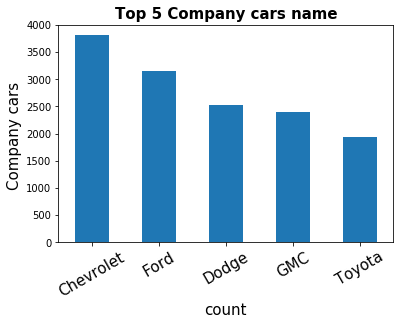

```python
fig, ax = plt.subplots()

ax.tick_params(axis='x', labelsize=15)
ax.tick_params(axis='y', labelsize=10)

ax.set_xlabel('count', fontsize=15)
ax.set_ylabel('Company cars ' , fontsize=15)
ax.set_title('Top 5 Company cars name', fontsize=15, fontweight='bold')

fuelMake[:5].plot(ax=ax, kind='bar')

plt.xticks(rotation=30);
```

The most used cars are Chevrolet , which is approximately 4000 users, followed by Ford, which are two powerful American companies, then it is followed by some American companies and others such as the Japanese and others

Next up, look at the distribution of the first predictor variable of interest: Years

```python
fuelyear = fuel['Year'].value_counts()
```

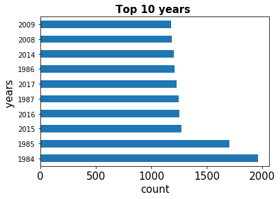

```python
fig, ax = plt.subplots()

ax.tick_params(axis='x', labelsize=15)
ax.tick_params(axis='y', labelsize=10)

ax.set_xlabel('count', fontsize=15)
ax.set_ylabel('years ' , fontsize=15)
ax.set_title('Top 10 years ', fontsize=15, fontweight='bold')

fuelyear[:10].plot(ax=ax, kind='barh')
plt.show()
```

Oh, it is surprising that the old cars are the top and almost 1985 cars while the latest ones on 2017 are in the 6th rank.

Before closing this section, we'll take a look at the last Three variables: Drive , Engine Cylinders and Fuel Type .

```python
fuelTrans = fuel['Transmission'].value_counts()
```

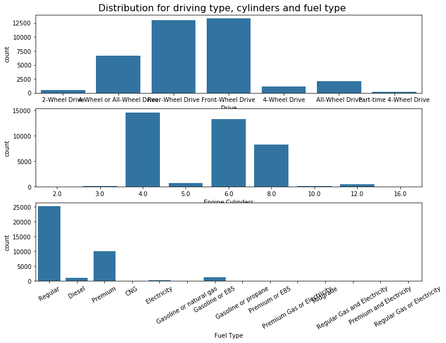

```python
fig, ax = plt.subplots(nrows=3, figsize = [11.69, 8.27])
default_color = sb.color_palette()[0]
g1 = sb.countplot(data = fuel, x = 'Drive', color = default_color, ax = ax[0])
g2 = sb.countplot(data = fuel, x = 'Engine Cylinders', color = default_color, ax = ax[1])
g3 = sb.countplot(data = fuel, x = 'Fuel Type', color = default_color, ax = ax[2])

fig.suptitle('Distribution for driving type, cylinders and fuel type', fontsize=16, y=.91)

plt.xticks(rotation=30);
```

We note that the higher driving type is the rear wheel and front wheel drive, which is economical. The most cylinders are 4 and then 6 and are somewhat uneconomical for the 6. The type of fuel is important in the economy, the most important of which is regular, but there is something strange about it, which is diesel. It is known that diesel is economical.

### Discuss the distribution(s) of your variable(s) of interest. Were there any unusual points? Did you need to perform any transformations?

It is surprising that we see the old exports of cars are the most, and also there are some of the most popular companies, which are Chevrolet and ford. I remember a piece of information in the community that 4 cylinders and 8 cylinders do not consume fuel like 6 cylinders. One of the factors most influenced by your consumption is the type of fuel.

### Of the features you investigated, were there any unusual distributions? Did you perform any operations on the data to tidy, adjust, or change the form of the data? If so, why did you do this?

No, because it is clear and does not require any modification or the like.

## Bivariate Exploration

To start off with, I want to look at the pairwise correlations present between features in the data.

```python
numeric_vars = ['Engine Cylinders', 'Engine Displacement', 'Combined MPG (FT1)']
categoric_vars = ['Supercharger', 'Turbocharger']
```

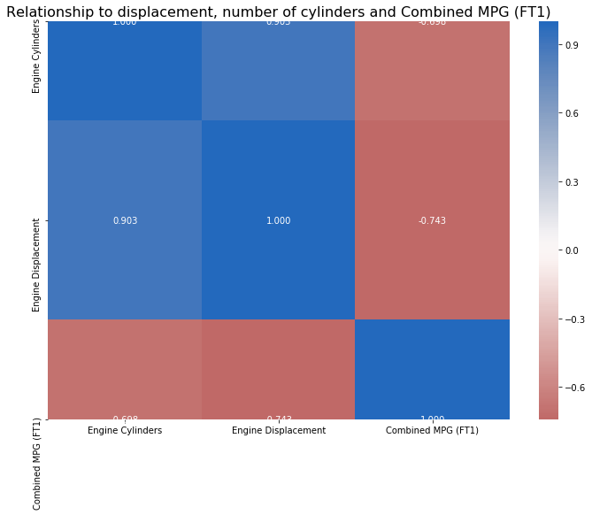

```python
# correlation plot
plt.figure(figsize = [11.69, 8.27])
sb.heatmap(fuel[numeric_vars].corr(), annot = True, fmt = '.3f',
           cmap = 'vlag_r', center = 0);
plt.title("Relationship to displacement, number of cylinders and Combined MPG (FT1)", fontsize =16)
plt.show()
```

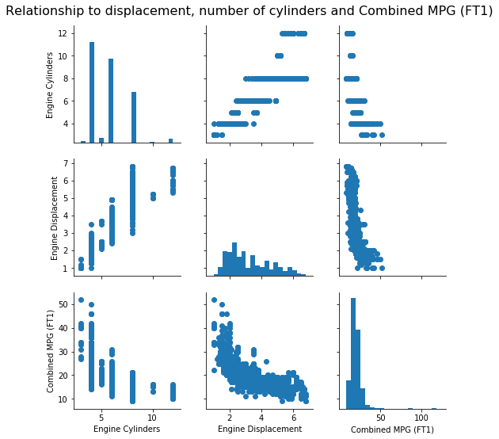

```python
# plot matrix: sample 2000 loans so that plots are clearer and render faster

samples = np.random.choice(fuel.shape[0], 2000, replace = False)
fuel_samp = fuel.loc[samples,:]
plt.figure(figsize = [11.69, 8.27])
g = sb.PairGrid(data = fuel_samp, vars = numeric_vars)
g = g.map_diag(plt.hist, bins = 20);
g.fig.suptitle("Relationship to displacement, number of cylinders and Combined MPG (FT1)", fontsize=16, y = 1.02)

g.map_offdiag(plt.scatter)
plt.show();
```

After looking at the demo, it became clear that the greater the number of cylinders, the greater the displacement, and this reflects the engine's power. Also, it turns out that the higher the Combined MPG (FT1), the lower the number of cylinders and the displacement, which means that fuel is saved with it.

Finally, Let's move on to looking at how Engine Cylinders , Engine Displacement and Combined MPG (FT1) with the categorical variables.

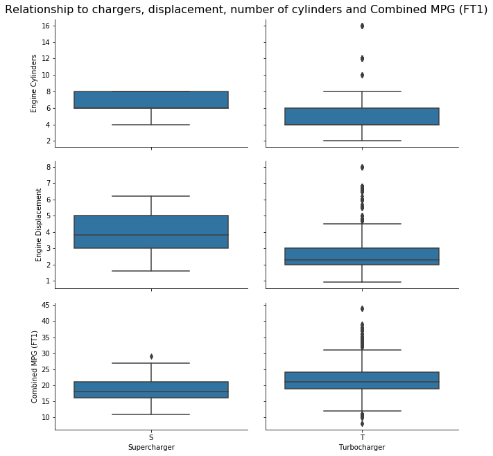

```python
# plot matrix of numeric features against categorical features.

def boxgrid(x, y, **kwargs):
    """ Quick hack for creating box plots with seaborn's PairGrid. """
    default_color = sb.color_palette()[0]
    sb.boxplot(x, y, color = default_color)


plt.figure(figsize = [11.69, 8.27])
g = sb.PairGrid(data = fuel, y_vars = ['Engine Cylinders', 'Engine Displacement', 'Combined MPG (FT1)'],
                x_vars = categoric_vars, size = 3, aspect = 1.5)
g.fig.suptitle("Relationship to chargers, displacement, number of cylinders and Combined MPG (FT1)", fontsize=16, y=1.01)
g.map(boxgrid)
plt.show();
```

Finally, let's look at relationships between the Two values features.

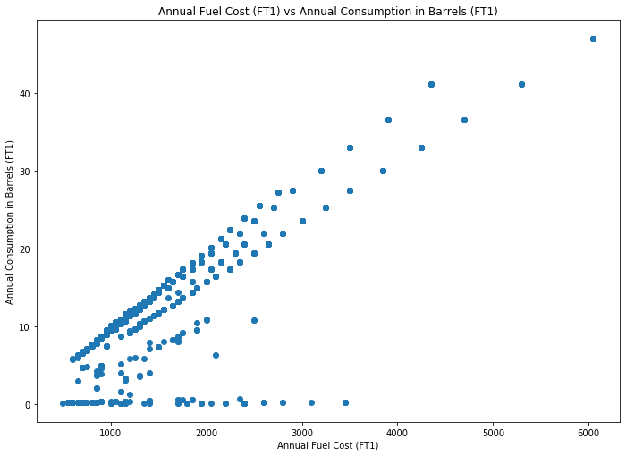

```python
# scatter plot of Annual Fuel Cost (FT1) vs Annual Consumption in Barrels (FT1)

plt.figure(figsize = [11.69, 8.27])
plt.scatter(data = fuel, x = 'Annual Fuel Cost (FT1)', y = 'Annual Consumption in Barrels (FT1)')
plt.xlabel('Annual Fuel Cost (FT1)')
plt.ylabel('Annual Consumption in Barrels (FT1)')
plt.title('Annual Fuel Cost (FT1) vs Annual Consumption in Barrels (FT1)')
plt.show()
```

Fuel costs and their consumption on an annual basis. It is reasonable to assume that the more shrimp is consumed, the greater its value. This applies to fuel, and it is a positive sign, although the costs increase, but this is profitable for the state as well.

### Multivariate Exploration

The main thing that I would like to know is what types of fuel are most used in highways and what is the type of driving and the relationship between fuel type to displacement, number of cylinders, and lastly. Is there a difference between chargers to fuel type and Combined MPG (FT1)?

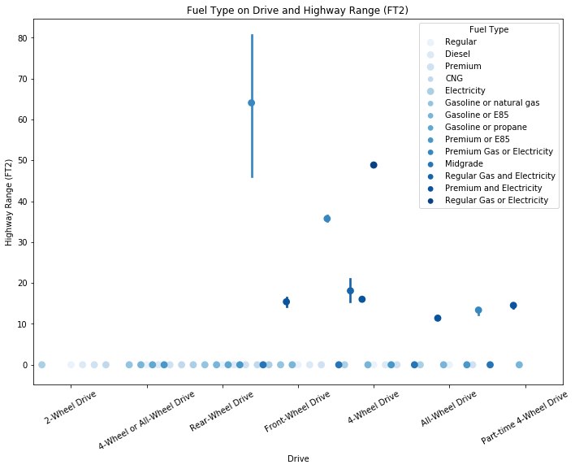

```python
fig = plt.figure(figsize = [11.69, 8.27])
ax = sb.pointplot(data = fuel, x = 'Drive', y = 'Highway Range (FT2)', hue = 'Fuel Type',
           palette = 'Blues', linestyles = '', dodge = 2)
plt.title('Fuel Type on Drive and Highway Range (FT2)')
plt.ylabel('Highway Range (FT2)')
plt.xlabel('Drive')
ax.set_yticklabels([],minor = True)
plt.xticks(rotation=30);
plt.show();
```

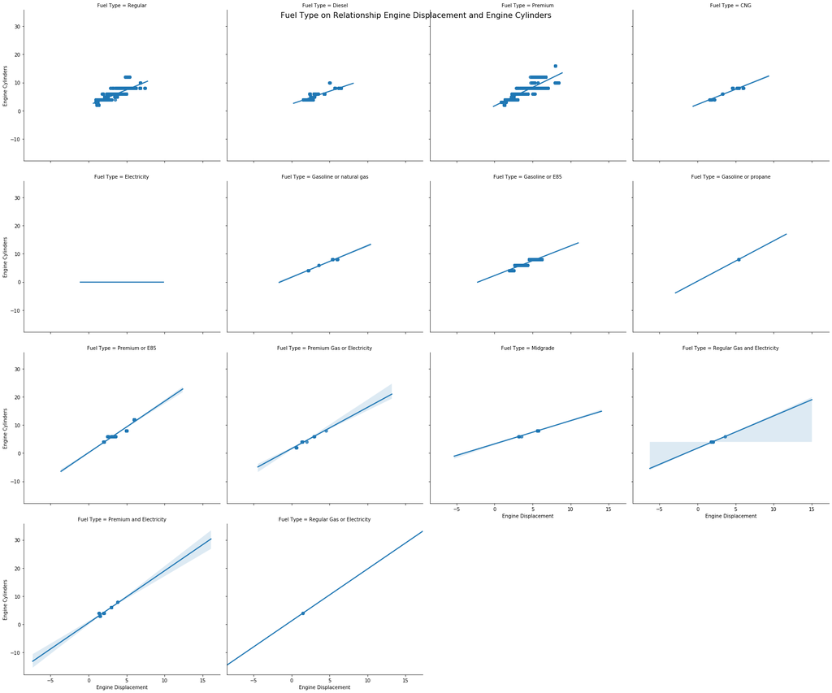

```python
# Fuel Type on Relationship Engine Displacement and Engine Cylinders
fig = plt.figure(figsize = [11.69, 8.27])
g=sb.FacetGrid(data=fuel, aspect=1.2, height=5, col='Fuel Type', col_wrap=4)
g.map(sb.regplot, 'Engine Displacement', 'Engine Cylinders', x_jitter=0.04);
g.fig.suptitle("Relationship to chargers, displacement, number of cylinders and Combined MPG (FT1)", fontsize=16);
g.fig.suptitle('Fuel Type on Relationship Engine Displacement and Engine Cylinders',fontsize=16)
plt.show();
g.add_legend()
```

Before closing this section, we'll take a look at chargers and what fuels are affected by them and Combined MPG.

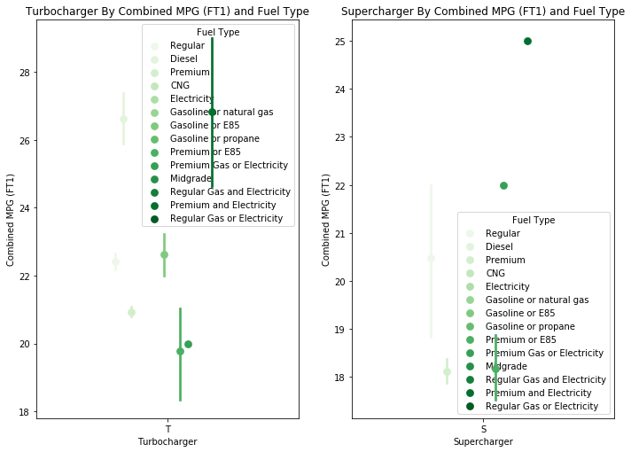

```python
fig, ax = plt.subplots(ncols = 2, figsize = [11.69, 8.27])

sb.pointplot(data = fuel, x = 'Turbocharger', y = 'Combined MPG (FT1)', hue = 'Fuel Type',
             palette = 'Greens', linestyles = '', dodge = 0.4, ax = ax[0])
ax[0].set_title('Turbocharger By Combined MPG (FT1) and Fuel Type')
ax[0].set_ylabel('Combined MPG (FT1)')

ax[0].set_yticklabels([],minor = True)

sb.pointplot(data = fuel, x = 'Supercharger', y = 'Combined MPG (FT1)', hue = 'Fuel Type',
             palette = 'Greens', linestyles = '', dodge = 0.4, ax = ax[1])
ax[1].set_title('Supercharger By Combined MPG (FT1) and Fuel Type')
ax[1].set_ylabel('Combined MPG (FT1)')

ax[1].set_yticklabels([],minor = True)
plt.show();
```